# Two frozen readers, one question: “who is Adolf Hitler?”

We asked two time-locked language models the same question, one hundred times each, and let them continue freely (sampling temperature 0.8). **Ranke 1913** has read nothing printed after 1913; **Ranke 1929** nothing after 1929. In 1913 Adolf Hitler was a twenty-four-year-old unknown in Vienna, rejected from art school. By 1929 he led the National Socialist party, had written *Mein Kampf* (1925) and stood trial for the 1923 Munich putsch — but was **not** yet Chancellor (that came in January 1933), and the war and the Holocaust were still in the future.

## What each model says he is (100 free continuations, prompt “Adolf Hitler is”)

| bucket | Ranke 1913 | Ranke 1929 |
| --- | --- | --- |
| situates the real Hitler (German radical politics) | 2% | 25% |
| empty name → generic person (often American) | 49% | 33% |
| other / vague confabulation | 49% | 42% |

Buckets are mutually exclusive and sum to 100. Tags are keyword rules, printed in src/hitler_analyze.py, and every rate can be checked against the quotations below.

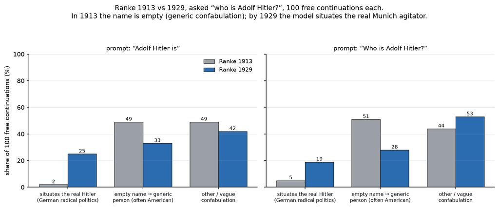

x-axis: the three buckets a continuation can fall in. y-axis: share of the 100 continuations in that bucket. Grey = the 1913 reader, blue = the 1929 reader. Left panel: the definitional prompt; right panel: the question as asked.

## Ranke 1913 — the name means nothing (six verbatim continuations)

- at the head of a great business in New York. He has many employees and he spends much time among them. One day as he was leaving his office, two young men stepped up to him with their hats off. Il beg your pardon" said one Of these young f
- an excellent example Of a man who has risen from humble origin to high position. The son of poor parents, he started out in life at the age Of Is without capital, and by economy saved sufficient money with which TO enter one OF the leading
- visiting friends in New York. Miss Edna Fitch has returned from a two weeks visit at Lake Mahopac. A. J.. Sackett of Newburg, n. Y. who owns the property on which the new town hall building Is to be erected will have charge Of erecting
- the name of an old gentleman who has been confined in the county Jail for three weeks. Mr.. Hillers case was called before Judge Smith and he plead guilty to a charge Of petty larceny but as this offense was not specified, it will be necess
- not the first man to claim that he had invented a perfect piano. In fact, there are several in ventors of this instrument before him. AS long ago as 1875 John Sebastian Bach conceived and practically executed a scheme for building music ro
- one Of the most sue cessful of American playwrights. and his latest piece, The Blue Bird" which comes to this city on Friday for a weeks engagement at the New National Theatre has been received with much approval in Chicago. where it was pr

## Ranke 1929 — the real Munich agitator (six verbatim continuations)

- at the head of new radical movement in Germany. The radicals have been divided into two factions, one composed Of moderate" Socialists and another consisting OF Communists. The former are now trying to force their program through without b
- an excellent man to keep out of the way Of big men, as he has proven on various occasions" This was one OF DR.. Charles A. Riehl's comments today after hear ing that Adolf I. Hitler would prob ably be appointed a member of the board OF dire
- reported to have said that the Communists are ready to take over and rule Germany. The French government has an nounced its intention Of occupying all of Eastern Prussia if Ger many does not fulfill her reparations obligations promptly.
- the man. In a recent issue of his newspaper, "Die Freiheit," he admits it. He has made an admission that should be enough for all time. But there are others in this country who have not accepted the fact so readily. They insist upon seeing
- not the first man to call himself king in Germany. On April Is, 1928, William Won Hohenzollern became emperor and took for his title that of Wilhelm Ii. The name was given him by Prussia when it made a treaty with Holland. In this treaty
- one Of the most for midable of German military lead ers and is also a well known editor in that country. He has been on an active campaign against the French government, as he considered it, but this did not keep him from being elected to t

## The honest caveat: neither model knows 1933

Where the 1929 model says “chancellor”, it is guessing, not remembering: it has him “made chancellor by King Ludwig II” (who died in 1886) or “called to that office by Emperor William”. No continuation from either model states the real January-1933 Chancellorship, the Reichstag fire, or anything of the war. The 1929 model knows the rising agitator of the 1920s; it does not know how the story ends — which is exactly the boundary the models were built to hold.